# Lecture 2 - Data structures, Reproducible Research, loading, cleaning and munging data in R

2020-08-22

## Today’s Agenda

- Review the concepts of Reproducible Research
- Review Git
- Importing, cleaning and munging data
- Summarizing and exploring data
- Vectors, matrices, and data frames

## Reproducible Research

### Review

This was the scenario:  
You had worked 6 months to analyze a data set. Someone else analyzes the data and comes to *different* conclusions. How good are your notes???

Answer: *Awesome, because you annotated your code with text to create a RR compendium*

## Reproducible Research - Concepts

*Basically just switching the role of code and comments in writing software*

Guide to this topic here: http://ropensci.github.io/reproducibility-guide/

In general, we should **weave** code and text into a complete reference of our work. The document should:

- download or otherwise load/generate data
- reproduce steps to munge data
- recreate analysis steps
- create figures and tables
- explain any and all steps along the way
- end with conclusions drawn
- optionally add suggestions for future experiments

## Version Control

What is version control - a system for storing data and tracking changes.

- Why should I use version control? http://stackoverflow.com/questions/1408450/why-should-i-use-version-control
- R and version control for the solo data analyst  
  http://stackoverflow.com/questions/2712421/r-and-version-control-for-the-solo-data-analyst

Thoughts or comments??

## Version Control and Git

Git is essentially a database of snapshots of the project directory tree. You decide when and what to take snapshots of and if you using GitHub (or similar) when to push a copy to a remote repository.

The basic workflow is:

1. git **pull**
2. **do work**
3. git **pull** to make sure you have latest files
4. git **add** *<your changed file>* tells git what change you care about
5. git **commit** -m “some INFORMATIVE message about the changes”
6. git **push** to the repository (local or remote)
7. repeat

## Git file states

- Untracked - files that have not been added to the database
- Committed - data is safely stored in your local database
- Modified - file is changed but not committed it to your database yet
- Staged - a modified file in its current version will go in next commit snapshot

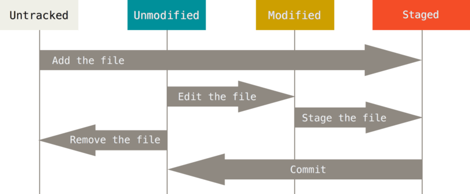

Git file lifecycle

## Back to Reproducible Research Analysis

Today we focus on getting and cleaning the data.

## Data wrangling

Data wrangling or munging is the process of going from raw to useful data. This can be 60-80% of the time spent on a project. Steps may include any or all of the following:

Step

Examples

Import

- read.table(html,json)

Clean

- filter and subset
- standardize
- renaming
- type conversions

Reformat

- merging
- reshaping
- aggregating

## Data wrangling – getting data

- load internal dataset

```r
    library(help = "datasets")
    ?PlantGrowth
```

- copy and paste
- load file
  - local
  - web

```r
    ?read.table; ?read.csv
    url<-"http://www2.isye.gatech.edu/~jeffwu/wuhamadabook/data/onewaymuzzle.dat"
    chp2_muzzle<-read.table(url,header=T)
    #google "how to get data into R"
```

- generate data

```r
    set.seed(123456)
    coin_flips<-rbinom(n = 1000,size = 1, prob = .501)
```

## Data importing – good practices

If you are getting data from the internet, it is a good idea to protect against:

1. data source being down
2. data source being changed
3. other unknown issues

I generally pull the data down, then save the data to an .Rds file. My project includes:

1. commented code used to pull data down
2. commented code used to save data
3. code to read data into R from the saved file
4. AND often project image files as mid-stream checkpoints

## Data wrangling - cleaning

Getting data into R is **usually** not the problem, often the fun starts when we start to actually look at what we were given. Common issues:

| issue | examples |
| --- | --- |
| missing values | recorded as “-”, “NA”,“0” |
| jagged arrays | missing fields |
| inconsistent data coding | 2017-01-22 vs 01-22-2017 vs Jan 22, 2017 |
| line termination | platform inconsistencies |
| field delimiter issues | csv has data values that use commas |

And pretty much any other issue you might imagine.

## Data wrangling - summarizing and tables

A quick way to see if there are issues with the data is to create a summary of the data. There are many useful metrics to capture, BUT, at a high level, here we really are most concerned with metrics associated with the data structure, i.e. number of observations, missing values, data types etc. R has a function for that… :)

```r
    ?str
    ?summary
    str(iris)
    summary(iris)
```

## Data wrangling - reformatting/standardizing

Now that we have the data in R, we need to get it into a useable format. One idea for a set of standards for structuring a data set is to create a so called “tidy” data set.

http://vita.had.co.nz/papers/tidy-data.html

Essentially, we need to reformat the data such that:

1. Each variable forms a column.
2. Each observation forms a row.
3. Each type of observational unit forms a table.

Any other structure to the data is considered messy. Sound easy?

## Data wrangling - reformatting

OK, what is wrong with this?

Messy Data

|  | treatmenta | treatmentb |
| --- | --- | --- |
| John Smith | NA | 2 |
| Jane Doe | 16 | 11 |
| Mary Johnson | 3 | 1 |

What we want is something more akin to a model:

\[ y_i = \beta_1 x_{i1} + \beta_2 x_{i2} ... \]

*Going to give this topic more time next week with the tidyverse*

To print the table in a document, we have several options. My current favorites are kable and stargazer. Other community tools include **Pander** and **xtable**.

## Data wrangling – other wrangling tasks

dplyr is another package by Hadley Wickam. As a practicing data scientist, he has a good feel for what functions we would like to see.

A few data processing goals enabled in dplyr

1. data summarizing
2. subsetting by observation
3. subsetting variables
4. creating new variables
5. grouping data
6. combining data

*look at Data Wrangling Cheatsheet*

## Data wrangling – quick plot summaries

Sometimes, a picture really is worth a 1000 words.

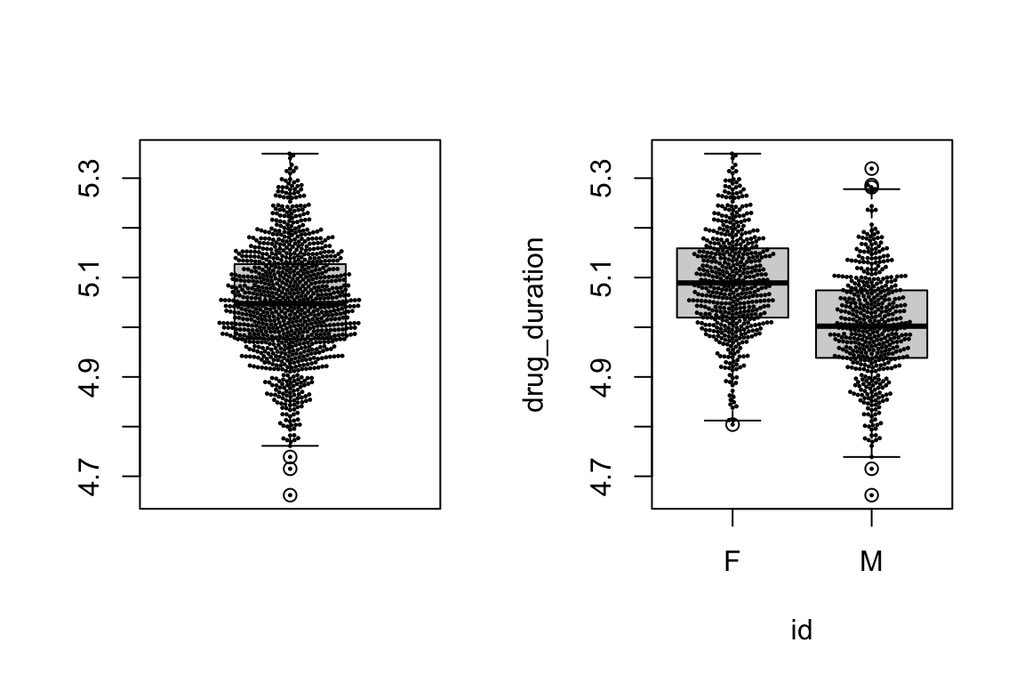

## Data wrangling – another quick plot

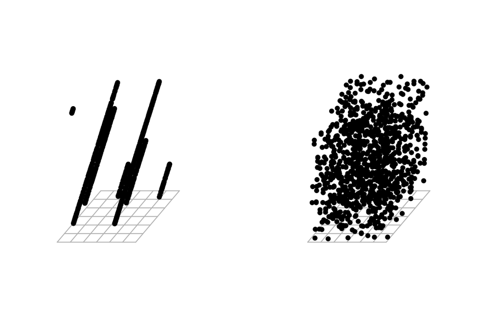

## Data wranging – common plots

1. histogram
2. box plot vs violin plot
3. scatter plot
4. pie chart, …

*don’t forget color and shape as dimensions*

## Remember – Good practices note

If you are getting data from the internet, it is a good idea to protect against:

1. data source being down
2. data source being changed
3. other unknown issues

I generally pull the data down, then save the data to a .Rds file. My project includes:

1. commented code used to pull data down
2. commented code used to save data
3. code to read data into R from the saved file
4. AND often project image files as mid-stream checkpoints

## Basic R data structures

- vector
- matrices (and arrays)
- data frame
- list

## Vectors

Vectors are data structures containing 1 or more elements of the same type. R knows about **logical, numeric (integer and double), character**, complex and raw. For instance:

```r
v<-1
v<-c(1,2)
v<-c("a","b")
```

Note 1: a scalar is a vector  
Note 2: v<-c(“a”,1) may not do what you want.

try: typeof(v), str(v), or class(v)

## Matrices

Matrices are the two dimensional version of vectors. All elements are of the same type. Arrays are the multi-dimensional equivalent to matrices, but are actually vectors.

```r
y<-matrix(LETTERS,nrow = 13)
rnames<-c(1:13)
cnames<-c("odds","evens")
y<-matrix(LETTERS,nrow = 13,byrow = T, dimnames=list(rnames,cnames))
z<-array(1:12,c(3,2,2))
str(z)
```

## Data Frames (and data tables)

Data frames are generic matrices meaning they can hold data of different types (by column).

```r
# ?data.frame
L3 <- LETTERS[1:3]
fac <- sample(L3, 10, replace = TRUE)
(d <- data.frame(x = 1, y = 1:10, fac = fac))
```

## Lists

### we won’t use this for a while

An unordered collection of objects. These can be useful in creating complex data types.

```r
name<-c("jack","jill","joe","jenny")
ages<-c(6,7,8,9)
people<-list(name=name,ages=ages)
people<-list()
people[["jack"]]<-data.frame(age=6,married="T",spouse="jill")
people[["jill"]]<-data.frame(age=6,married="T",spouse="jack")
people[["joe"]]<-data.frame(age=6,married="F")
```

## Examples

### simple calculations

1. calculate sum of 1^2 + 2^2 + … + 400^2
2. calculate sum of 1*2 + 2*3 + 3*4 + … + 249*250

## Example

### Numerical integration using Riemann sum

\(\int_0^{\pi/6}cos(x) dx\)

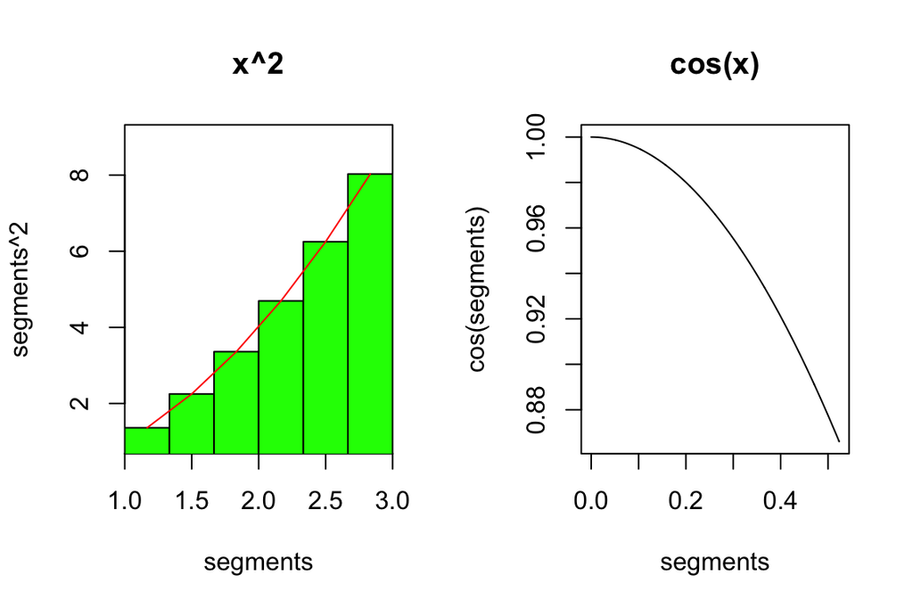

## Example

### Solve system of equations

\[ \begin{aligned} x_1 - 2x_2 &= -1 \\ -x_1 + 3x_2 &= 3 \end{aligned} \] Can be written:

\[ \begin{aligned} \begin{pmatrix} 1 & -2 \\ -1 & 3 \end{pmatrix} \begin{pmatrix} x_1 \\ x_2\end{pmatrix} = \begin{pmatrix} -1 \\ 3\end{pmatrix} \end{aligned} \] OR, solving:

\[ \begin{aligned} \begin{pmatrix} x_1 \\ x_2\end{pmatrix} = \begin{pmatrix} 1 & -2 \\ -1 & 3 \end{pmatrix}^{-1} \begin{pmatrix} -1 \\ 3\end{pmatrix} \end{aligned} \]

## Next up

- In-class munging
- Homework 2